# Lab 2

GitHub link: https://github.com/TylerWolfWilliams/GSB-544

```python
from plotnine import *
import pandas as pd
import numpy as np
```

1. The dataset appears to contain data on the price and volume of avocados tied to a specific geography and date.
2. I am pulling out the cities from the geography column using a list of the most populous cities in the US I found online, which contains city and its associated state, and then filtering to find the “extra” geographies. These I will then manually separate into regions or other levels (Total U.S.). I had to add Boise, Harrisburg, and Roanoke to the Cities dataset manually, and I lastly separated date into day, month, and year columns

```python
df = pd.read_csv("C:/Users/tyler/OneDrive/Desktop/GSB-544/Lab 2/avocado-updated-2020.csv")
cities = pd.read_csv("C:/Users/tyler/OneDrive/Desktop/GSB-544/Lab 2/US-Cities.csv")

# Renaming columns for readability
df.rename(columns={'4046': 'small_volume', '4225': 'large_volume', '4770': 'xlarge_volume'}, inplace=True)

# Cleaning geography column for filtering
df['geography'] = (df['geography'].str.lower().str.strip().str.split('/').str[0].str.strip())

# Cleaning city and state columns for filtering
cities['city'] = cities['city'].str.lower().str.strip()
cities['state'] = cities['state'].str.lower().str.strip()

# Separating out date values
df['date'] = pd.to_datetime(df['date'], format='%m/%d/%Y')
df['day'] = df['date'].dt.day
df['month'] = df['date'].dt.month
df['year'] = df['date'].dt.year

# Filtering for country, cities, and states in geography column
df_cities = df.loc[df['geography'].isin(cities['city'])].copy()
df_states = df.loc[df['geography'].isin(cities['state'])].copy()
df_country = df.loc[df['geography'] == "total u.s."]

# Filtering for region (all rows not in df_cities, df_states, df_country)
matched = set(df_cities['geography']).union(set(df_states['geography'])).union(set(df_country['geography']))
df_region = df.loc[~df['geography'].isin(matched)].copy()
```

3. I can now sort by year in my df_region table and find the region with the largest small_volume. We can see that West is the region with the largest small_volume in 2017

```python
# Finding the sum of small_volume for each region across 2017
mask = (df_region['year'] == 2017) & (df_region['type'] == 'organic')
region_totals = df_region.loc[mask].groupby('geography', as_index=False)['small_volume'].sum()
region_totals.loc[region_totals['small_volume'].idxmax()]
```

```
geography             west
small_volume    1870206.29
Name: 7, dtype: object
```

4. I can also use the previously created month column to find the month with highest total volume. We can see that May has the highest total_volume.

```python
# Finding the sum of total_volume for each month
monthly_totals = df.groupby('month', as_index=False)['total_volume'].sum().astype(int)
monthly_totals.loc[monthly_totals['total_volume'].idxmax()]
```

```
month                    5
total_volume    3276511653
Name: 4, dtype: int64
```

5. I found the mean of total_volume for each city, and then filtered for the top 5. We can see in the plot that LA has the highest average.

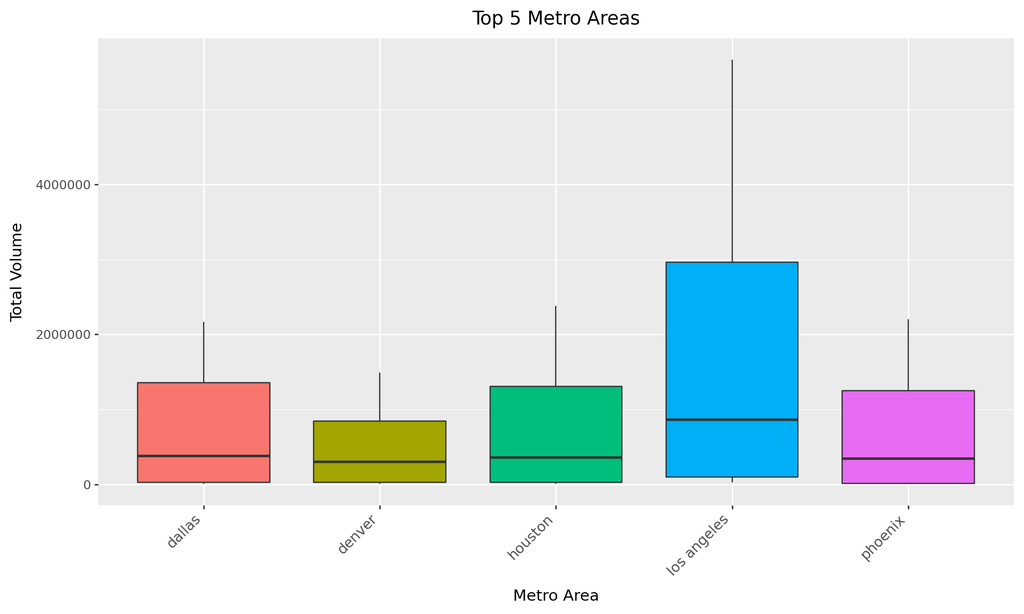

```python
# Finding the sum of total_volume for each region
top5 = df_cities.groupby('geography', as_index=False)['total_volume'].mean().sort_values('total_volume', ascending=False).head(5)

df_top5 = df_cities[df_cities['geography'].isin(top5['geography'])].copy()

(ggplot(df_top5,
aes(
    x='geography',
    y='total_volume',
    fill='geography'
))
+ geom_boxplot(show_legend=False)
+ labs(
    title='Top 5 Metro Areas',
    x='Metro Area',
    y='Total Volume'
    )
+ theme(
    axis_text_x=element_text(rotation=45, ha='right', size=10),
    figure_size=(10, 6)
    )
)
```

6. Creating the california subset

```python
df_cali = df.loc[df['geography'].isin({"los angeles", "sacramento", "san francisco", "san diego"})].copy()
```

7. I gathered the summary statistics of the average_price in each of the 4 california regions. I then calculated price difference and plotted the regions by it.

```
       geography          type      mean  median       std  count
0    los angeles  conventional  1.047124   1.020  0.231167    306
1    los angeles       organic  1.574902   1.585  0.311722    306
2     sacramento  conventional  1.295359   1.260  0.219177    306
3     sacramento       organic  1.873856   1.840  0.292875    306
4      san diego  conventional  1.113856   1.090  0.242960    306
5      san diego       organic  1.798366   1.800  0.331655    306
6  san francisco  conventional  1.400490   1.390  0.272060    306
7  san francisco       organic  2.119444   2.060  0.395854    306
type           conventional   organic      diff
geography
san francisco      1.400490  2.119444  0.718954
san diego          1.113856  1.798366  0.684510
sacramento         1.295359  1.873856  0.578497
los angeles        1.047124  1.574902  0.527778
```

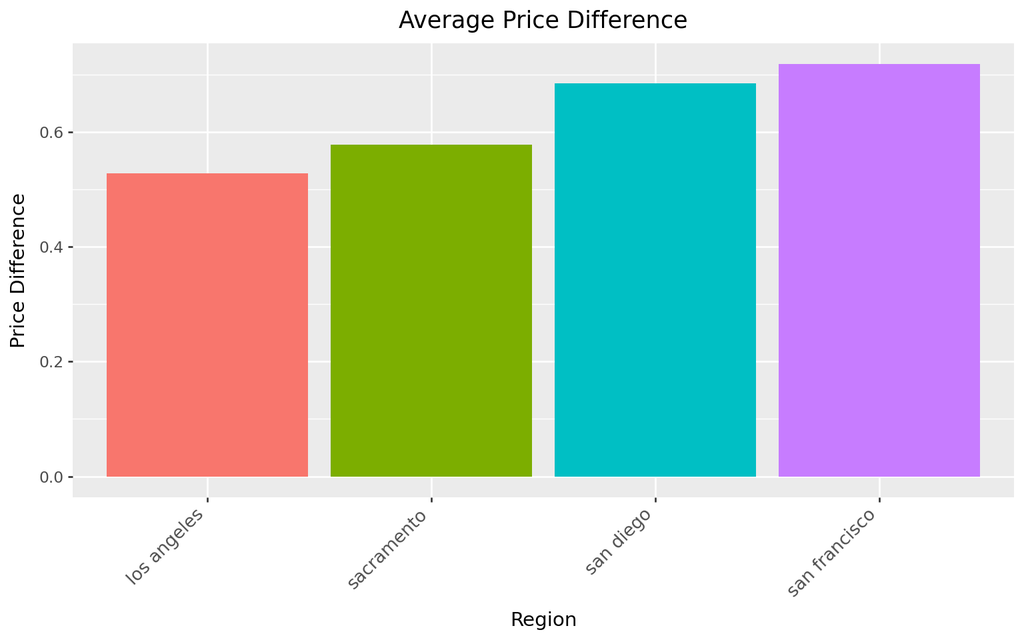

```python
# Gathering summary statistics
summary = df_cali.groupby(['geography', 'type'])['average_price'].agg(['mean', 'median', 'std', 'count']).reset_index()
print(summary)

price_diff = summary.pivot(index='geography', columns='type', values='mean')
price_diff['diff'] = price_diff['organic'] - price_diff['conventional']
price_diff = price_diff.sort_values('diff', ascending=False)
print(price_diff)

price_diff = price_diff.reset_index()

(ggplot(price_diff,
aes(
    x='geography',
    y='diff',
    fill='geography'
))
+ geom_col(show_legend=False)
+ labs(
    title='Average Price Difference',
    x='Region',
    y='Price Difference'
    )
+ theme(
    axis_text_x=element_text(rotation=45, ha='right', size=10),
    figure_size=(8, 5)
    )
)
```

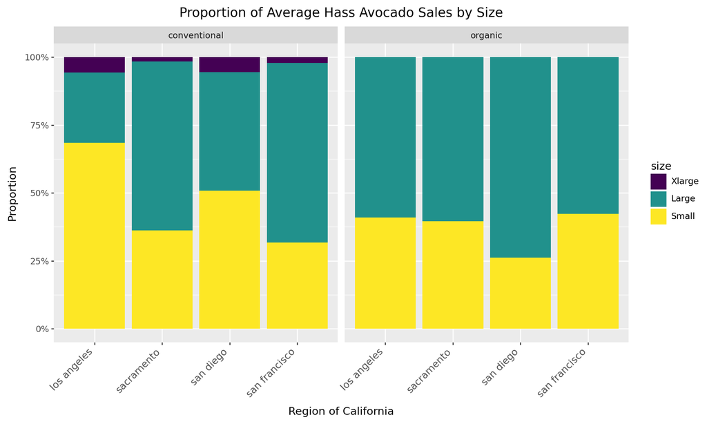

```python
# Creating a single size column
df_cali['size'] = df_cali[['small_volume', 'large_volume', 'xlarge_volume']].idxmax(axis=1)

df_melt = df_cali.melt(
    id_vars=['geography', 'type'],
    value_vars=['small_volume', 'large_volume', 'xlarge_volume'],
    var_name='size',
    value_name='volume'
)

# Removing _volume from size names
df_melt['size'] = df_melt['size'].str.replace('_volume', '').str.title()

# Compute total and proportions within each geography and type
df_prop = df_melt.groupby(['geography', 'type', 'size'], as_index=False)['volume'].mean()
df_prop['proportion'] = df_prop.groupby(['geography', 'type'])['volume'].apply(lambda x: x / x.sum()).reset_index(drop=True)

# Manually defining order of size
df_prop['size'] = pd.Categorical(df_prop['size'], categories=['Xlarge', 'Large', 'Small'], ordered=True)

(ggplot(df_prop,
aes(
    x='geography',
    y='proportion',
    fill='size'
))
+ geom_bar(stat='identity', position='stack')
+ facet_wrap('~type')
+ scale_y_continuous(
    breaks=[0, 0.25, 0.50, 0.75, 1.00],
    labels=["0%", "25%", "50%", "75%", "100%"]
    )
+ labs(
    title='Proportion of Average Hass Avocado Sales by Size',
    x='Region of California',
    y='Proportion'
    )
+ theme(
    axis_text_x=element_text(rotation=45, ha='right', size=10),
    figure_size=(10, 6)
    )
)
```

9. Looking at housing data

The plot shows a generally negative relationship between housing market health and avocado prices across the four California metro areas. In cities like Los Angeles and San Diego, higher rates of mortgage delinquency are associated with lower avocado prices, suggesting reduced consumer spending power. On the other hand, San Francisco, which maintains low delinquency rates, shows the highest avocado prices. Overall, regions with stronger housing markets tend to support higher avocado prices, meaning there could be a connection between ability to buy a house and ability to buy avocado toast.

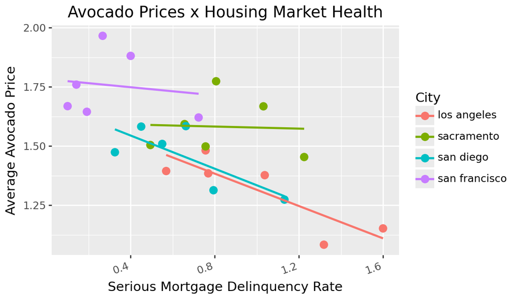

```python
mortgage = pd.read_csv("C:/Users/tyler/OneDrive/Desktop/GSB-544/Lab 2/nmdb-mortgage-performance-statistics-metros-quarterly.csv")

# Filter for California metros and the house price index indicator
housing = mortgage.loc[
    mortgage['GEONAME'].isin([
        'Los Angeles-Long Beach-Glendale, CA (MSAD)',
        'San Francisco-San Mateo-Redwood City, CA (MSAD)',
        'San Diego-Chula Vista-Carlsbad, CA',
        'Sacramento-Roseville-Folsom, CA'
    ])].copy()

rename = {
    'Los Angeles-Long Beach-Glendale, CA (MSAD)': 'los angeles',
    'San Francisco-San Mateo-Redwood City, CA (MSAD)': 'san francisco',
    'San Diego-Chula Vista-Carlsbad, CA': 'san diego',
    'Sacramento-Roseville-Folsom, CA': 'sacramento'
}
housing['city'] = housing['GEONAME'].map(rename)


# Filter for serious delinquency rate (90+ days past due)
housing = housing[housing['SERIESID'] == 'P90DL']

# Average by metro and year
house_agg = housing.groupby(['city','YEAR'], as_index=False)['VALUE1'].mean()
house_agg = house_agg.rename(columns={'VALUE1':'delinquency_rate', 'YEAR':'year'})

# Merging with df_cali
df_cali = df_cali.rename(columns={'geography':'city'})
df_joined = df_cali.groupby(['city','year'], as_index=False)['average_price'].mean()
merged = pd.merge(df_joined, house_agg, on=['city','year'], how='inner')

(ggplot(merged,
aes(
    x='delinquency_rate',
    y='average_price',
    color='city'))
+ geom_point(size=3)
+ geom_smooth(method='lm', se=False)
+ labs(
    title='Avocado Prices x Housing Market Health',
    x='Serious Mortgage Delinquency Rate',
    y='Average Avocado Price',
    color='City'
    )
+ theme(axis_text_x=element_text(rotation=20, ha='right'))
)
```